# Communicate Data Findings Project

This project has two parts that demonstrate the importance and value of data visualization techniques in the data analysis process. In the first part, you will use Python visualization libraries to systematically explore a selected dataset, starting from plots of single variables and building up to plots of multiple variables. In the second part, you will produce a short presentation that illustrates interesting properties, trends, and relationships that you discovered in your selected dataset. The primary method of conveying your findings will be through transforming your exploratory visualizations from the first part into polished, explanatory visualizations.

# Ford GoBike System

# Data Wrangling

## Step 1: Gather

import all libary

```python
import pandas as pd
import numpy as np
import matplotlib.pyplot as plt
from matplotlib import figure
from matplotlib.pyplot import figure
from matplotlib.ticker import FuncFormatter
import seaborn as sns
import seaborn as sb
%matplotlib inline
```

load datset

```python
Data = pd.read_csv(r'C:\Users\Bassa\Desktop\DAND\Communicate Data Findings By Bassam Mohammed\201902-fordgobike-tripdata.csv')
print(Data.shape)
Data.head(10)
```

```
(183412, 16)
```

|  | duration_sec | start_time | end_time | start_station_id | start_station_name | start_station_latitude | start_station_longitude | end_station_id | end_station_name | end_station_latitude | end_station_longitude | bike_id | user_type | member_birth_year | member_gender | bike_share_for_all_trip |
| --- | --- | --- | --- | --- | --- | --- | --- | --- | --- | --- | --- | --- | --- | --- | --- | --- |
| 0 | 52185 | 2019-02-28 17:32:10.1450 | 2019-03-01 08:01:55.9750 | 21.0 | Montgomery St BART Station (Market St at 2nd St) | 37.789625 | -122.400811 | 13.0 | Commercial St at Montgomery St | 37.794231 | -122.402923 | 4902 | Customer | 1984.0 | Male | No |
| 1 | 42521 | 2019-02-28 18:53:21.7890 | 2019-03-01 06:42:03.0560 | 23.0 | The Embarcadero at Steuart St | 37.791464 | -122.391034 | 81.0 | Berry St at 4th St | 37.775880 | -122.393170 | 2535 | Customer | NaN | NaN | No |
| 2 | 61854 | 2019-02-28 12:13:13.2180 | 2019-03-01 05:24:08.1460 | 86.0 | Market St at Dolores St | 37.769305 | -122.426826 | 3.0 | Powell St BART Station (Market St at 4th St) | 37.786375 | -122.404904 | 5905 | Customer | 1972.0 | Male | No |
| 3 | 36490 | 2019-02-28 17:54:26.0100 | 2019-03-01 04:02:36.8420 | 375.0 | Grove St at Masonic Ave | 37.774836 | -122.446546 | 70.0 | Central Ave at Fell St | 37.773311 | -122.444293 | 6638 | Subscriber | 1989.0 | Other | No |
| 4 | 1585 | 2019-02-28 23:54:18.5490 | 2019-03-01 00:20:44.0740 | 7.0 | Frank H Ogawa Plaza | 37.804562 | -122.271738 | 222.0 | 10th Ave at E 15th St | 37.792714 | -122.248780 | 4898 | Subscriber | 1974.0 | Male | Yes |
| 5 | 1793 | 2019-02-28 23:49:58.6320 | 2019-03-01 00:19:51.7600 | 93.0 | 4th St at Mission Bay Blvd S | 37.770407 | -122.391198 | 323.0 | Broadway at Kearny | 37.798014 | -122.405950 | 5200 | Subscriber | 1959.0 | Male | No |
| 6 | 1147 | 2019-02-28 23:55:35.1040 | 2019-03-01 00:14:42.5880 | 300.0 | Palm St at Willow St | 37.317298 | -121.884995 | 312.0 | San Jose Diridon Station | 37.329732 | -121.901782 | 3803 | Subscriber | 1983.0 | Female | No |
| 7 | 1615 | 2019-02-28 23:41:06.7660 | 2019-03-01 00:08:02.7560 | 10.0 | Washington St at Kearny St | 37.795393 | -122.404770 | 127.0 | Valencia St at 21st St | 37.756708 | -122.421025 | 6329 | Subscriber | 1989.0 | Male | No |
| 8 | 1570 | 2019-02-28 23:41:48.7900 | 2019-03-01 00:07:59.7150 | 10.0 | Washington St at Kearny St | 37.795393 | -122.404770 | 127.0 | Valencia St at 21st St | 37.756708 | -122.421025 | 6548 | Subscriber | 1988.0 | Other | No |
| 9 | 1049 | 2019-02-28 23:49:47.6990 | 2019-03-01 00:07:17.0250 | 19.0 | Post St at Kearny St | 37.788975 | -122.403452 | 121.0 | Mission Playground | 37.759210 | -122.421339 | 6488 | Subscriber | 1992.0 | Male | No |

## Step 2: Gather

```python
Data.info()
```

```
<class 'pandas.core.frame.DataFrame'>
RangeIndex: 183412 entries, 0 to 183411
Data columns (total 16 columns):
 #   Column                   Non-Null Count   Dtype
---  ------                   --------------   -----
 0   duration_sec             183412 non-null  int64
 1   start_time               183412 non-null  object
 2   end_time                 183412 non-null  object
 3   start_station_id         183215 non-null  float64
 4   start_station_name       183215 non-null  object
 5   start_station_latitude   183412 non-null  float64
 6   start_station_longitude  183412 non-null  float64
 7   end_station_id           183215 non-null  float64
 8   end_station_name         183215 non-null  object
 9   end_station_latitude     183412 non-null  float64
 10  end_station_longitude    183412 non-null  float64
 11  bike_id                  183412 non-null  int64
 12  user_type                183412 non-null  object
 13  member_birth_year        175147 non-null  float64
 14  member_gender            175147 non-null  object
 15  bike_share_for_all_trip  183412 non-null  object
dtypes: float64(7), int64(2), object(7)
memory usage: 22.4+ MB
```

```python
Data.isnull().sum()
```

```
duration_sec                  0
start_time                    0
end_time                      0
start_station_id            197
start_station_name          197
start_station_latitude        0
start_station_longitude       0
end_station_id              197
end_station_name            197
end_station_latitude          0
end_station_longitude         0
bike_id                       0
user_type                     0
member_birth_year          8265
member_gender              8265
bike_share_for_all_trip       0
dtype: int64
```

```python
#check duplicated record
Data.duplicated().sum()
```

```
0
```

```python
Data.sample(7)
```

|  | duration_sec | start_time | end_time | start_station_id | start_station_name | start_station_latitude | start_station_longitude | end_station_id | end_station_name | end_station_latitude | end_station_longitude | bike_id | user_type | member_birth_year | member_gender | bike_share_for_all_trip |
| --- | --- | --- | --- | --- | --- | --- | --- | --- | --- | --- | --- | --- | --- | --- | --- | --- |
| 12652 | 247 | 2019-02-27 17:25:35.2690 | 2019-02-27 17:29:42.7810 | 20.0 | Mechanics Monument Plaza (Market St at Bush St) | 37.791300 | -122.399051 | 26.0 | 1st St at Folsom St | 37.787290 | -122.394380 | 5589 | Customer | 1994.0 | Female | No |
| 149508 | 235 | 2019-02-06 19:16:37.5950 | 2019-02-06 19:20:32.8800 | 134.0 | Valencia St at 24th St | 37.752428 | -122.420628 | 131.0 | 22nd St at Dolores St | 37.755000 | -122.425728 | 4722 | Subscriber | 1987.0 | Female | No |
| 131907 | 799 | 2019-02-09 10:21:00.5250 | 2019-02-09 10:34:19.5500 | 197.0 | El Embarcadero at Grand Ave | 37.808848 | -122.249680 | 207.0 | Broadway at Coronado Ave | 37.835788 | -122.251621 | 4856 | Customer | 1990.0 | Female | No |
| 106216 | 386 | 2019-02-13 18:37:59.6470 | 2019-02-13 18:44:25.8440 | 43.0 | San Francisco Public Library (Grove St at Hyde... | 37.778768 | -122.415929 | 90.0 | Townsend St at 7th St | 37.771058 | -122.402717 | 6188 | Subscriber | 1974.0 | Male | No |
| 102248 | 450 | 2019-02-14 16:45:17.3530 | 2019-02-14 16:52:48.2460 | 22.0 | Howard St at Beale St | 37.789756 | -122.394643 | 81.0 | Berry St at 4th St | 37.775880 | -122.393170 | 5537 | Subscriber | 1979.0 | Male | No |
| 149627 | 447 | 2019-02-06 19:03:28.4190 | 2019-02-06 19:10:55.5360 | 16.0 | Steuart St at Market St | 37.794130 | -122.394430 | 19.0 | Post St at Kearny St | 37.788975 | -122.403452 | 3569 | Subscriber | 1982.0 | Male | No |
| 88283 | 321 | 2019-02-16 19:17:48.4130 | 2019-02-16 19:23:09.5780 | 119.0 | 18th St at Noe St | 37.761047 | -122.432642 | 133.0 | Valencia St at 22nd St | 37.755213 | -122.420975 | 6282 | Subscriber | 1984.0 | Male | No |

# Observation.

## Tidiness Issues :

- Add start_of_weekday columns take day name from start time
- Add start_hour columns take hour from strat time
- Add end_hour columns take hour from end _time
- Add duration_minites take min from duration_sec then divied 60
- Add age_member take age from member_birth_year columns

# Cleaning

## Define:

## Code

```python
Data.start_time = pd.to_datetime(Data.start_time)
Data.end_time = pd.to_datetime(Data.end_time)
```

## Test:

```python
print(Data.start_time.dtype)
print(Data.end_time.dtype)
```

```
datetime64[ns]
datetime64[ns]
```

## Define:

Null values recorded as NaN

## Code

```python
Data = Data.dropna()
```

## Test:

```python
Data.isnull().sum()
```

```
duration_sec               0
start_time                 0
end_time                   0
start_station_id           0
start_station_name         0
start_station_latitude     0
start_station_longitude    0
end_station_id             0
end_station_name           0
end_station_latitude       0
end_station_longitude      0
bike_id                    0
user_type                  0
member_birth_year          0
member_gender              0
bike_share_for_all_trip    0
dtype: int64
```

## Define:

- Add start_of_weekday columns take day name from start time
- Add start_hour columns take hour from strat time
- Add end_hour columns take hour from end _time
- Add duration_minites take min from duration_sec then divied 60
- Add age_member take age from member_birth_year columns

## Code

```python
Data['start_of_weekday'] = Data['start_time'].dt.strftime('%a')
```

```python
Data['start_hour'] = Data['start_time'].dt.hour
```

```python
Data['end_hour'] = Data['end_time'].dt.hour
```

```python
Data['duration_minites'] = Data['duration_sec']/60
```

```python
Data['age_member'] = 2021 - Data['member_birth_year']
```

## Test:

```python
print(Data.columns)
```

```
Index(['duration_sec', 'start_time', 'end_time', 'start_station_id',
       'start_station_name', 'start_station_latitude',
       'start_station_longitude', 'end_station_id', 'end_station_name',
       'end_station_latitude', 'end_station_longitude', 'bike_id', 'user_type',
       'member_birth_year', 'member_gender', 'bike_share_for_all_trip',
       'start_of_weekday', 'start_hour', 'end_hour', 'duration_minites',
       'age_member'],
      dtype='object')
```

```python
Data.sample(100)
```

|  | duration_sec | start_time | end_time | start_station_id | start_station_name | start_station_latitude | start_station_longitude | end_station_id | end_station_name | end_station_latitude | ... | bike_id | user_type | member_birth_year | member_gender | bike_share_for_all_trip | start_of_weekday | start_hour | end_hour | duration_minites | age_member |
| --- | --- | --- | --- | --- | --- | --- | --- | --- | --- | --- | --- | --- | --- | --- | --- | --- | --- | --- | --- | --- | --- |
| 135515 | 1143 | 2019-02-08 12:27:25.564 | 2019-02-08 12:46:29.146 | 256.0 | Hearst Ave at Euclid Ave | 37.875112 | -122.260553 | 249.0 | Russell St at College Ave | 37.858473 | ... | 4868 | Subscriber | 1991.0 | Male | No | Fri | 12 | 12 | 19.050000 | 30.0 |
| 49077 | 114 | 2019-02-22 00:50:07.532 | 2019-02-22 00:52:01.930 | 121.0 | Mission Playground | 37.759210 | -122.421339 | 109.0 | 17th St at Valencia St | 37.763316 | ... | 6118 | Subscriber | 1991.0 | Male | No | Fri | 0 | 0 | 1.900000 | 30.0 |
| 77971 | 1159 | 2019-02-18 21:42:41.234 | 2019-02-18 22:02:00.521 | 174.0 | Shattuck Ave at 51st St | 37.836801 | -122.264004 | 200.0 | 2nd Ave at E 18th St | 37.800214 | ... | 6603 | Subscriber | 1977.0 | Male | No | Mon | 21 | 22 | 19.316667 | 44.0 |
| 92342 | 279 | 2019-02-15 19:14:26.906 | 2019-02-15 19:19:06.118 | 200.0 | 2nd Ave at E 18th St | 37.800214 | -122.253810 | 201.0 | 10th St at Fallon St | 37.797673 | ... | 4841 | Subscriber | 1993.0 | Female | No | Fri | 19 | 19 | 4.650000 | 28.0 |
| 117177 | 530 | 2019-02-12 01:15:02.898 | 2019-02-12 01:23:53.438 | 134.0 | Valencia St at 24th St | 37.752428 | -122.420628 | 58.0 | Market St at 10th St | 37.776619 | ... | 5474 | Subscriber | 1994.0 | Female | No | Tue | 1 | 1 | 8.833333 | 27.0 |
| ... | ... | ... | ... | ... | ... | ... | ... | ... | ... | ... | ... | ... | ... | ... | ... | ... | ... | ... | ... | ... | ... |
| 31047 | 590 | 2019-02-24 17:42:16.699 | 2019-02-24 17:52:06.804 | 8.0 | The Embarcadero at Vallejo St | 37.799953 | -122.398525 | 3.0 | Powell St BART Station (Market St at 4th St) | 37.786375 | ... | 4397 | Subscriber | 1985.0 | Male | No | Sun | 17 | 17 | 9.833333 | 36.0 |
| 147376 | 609 | 2019-02-07 07:52:23.397 | 2019-02-07 08:02:32.857 | 321.0 | 5th St at Folsom | 37.780146 | -122.403071 | 13.0 | Commercial St at Montgomery St | 37.794231 | ... | 5382 | Subscriber | 1995.0 | Male | No | Thu | 7 | 8 | 10.150000 | 26.0 |
| 147349 | 329 | 2019-02-07 07:58:43.624 | 2019-02-07 08:04:13.610 | 249.0 | Russell St at College Ave | 37.858473 | -122.253253 | 171.0 | Rockridge BART Station | 37.844279 | ... | 4594 | Subscriber | 1989.0 | Male | No | Thu | 7 | 8 | 5.483333 | 32.0 |
| 29137 | 428 | 2019-02-25 07:53:02.235 | 2019-02-25 08:00:10.354 | 66.0 | 3rd St at Townsend St | 37.778742 | -122.392741 | 324.0 | Union Square (Powell St at Post St) | 37.788300 | ... | 5409 | Subscriber | 1985.0 | Male | No | Mon | 7 | 8 | 7.133333 | 36.0 |
| 121638 | 262 | 2019-02-11 14:35:29.860 | 2019-02-11 14:39:52.342 | 183.0 | Telegraph Ave at 19th St | 37.808702 | -122.269927 | 164.0 | Isabella St at San Pablo Ave | 37.814988 | ... | 5074 | Subscriber | 1984.0 | Male | Yes | Mon | 14 | 14 | 4.366667 | 37.0 |

100 rows × 21 columns

```python
Data['start_of_weekday'].value_counts()
```

```
Thu    33712
Tue    30584
Wed    28426
Fri    27663
Mon    25641
Sun    14512
Sat    14414
Name: start_of_weekday, dtype: int64
```

```python
Data['start_hour'].value_counts()
```

```
17    20904
8     20227
18    16118
9     15204
16    13473
7     10231
19     9424
15     8646
12     8220
13     8098
10     7970
14     7677
11     7461
20     6211
21     4400
6      3293
22     2793
23     1572
0       893
5       866
1       525
2       355
4       227
3       164
Name: start_hour, dtype: int64
```

```python
Data['end_hour'].value_counts()
```

```
17    20322
8     19012
18    17468
9     16973
16    12526
19    10227
10     8538
7      8448
15     8292
12     8139
13     8086
14     7696
11     7212
20     6622
21     4701
22     3099
6      2802
23     1747
0       965
5       738
1       541
2       405
4       225
3       168
Name: end_hour, dtype: int64
```

```python
Data['age_member'].value_counts()
```

```
33.0     10214
28.0      9323
32.0      8967
31.0      8640
30.0      8484
         ...
94.0         1
111.0        1
91.0         1
143.0        1
93.0         1
Name: age_member, Length: 75, dtype: int64
```

```python
Data['member_gender'].value_counts()
```

```
Male      130500
Female     40805
Other       3647
Name: member_gender, dtype: int64
```

```python
#clenning Drop other
drop_other = Data[Data['member_gender']=='Other'].index
Data = Data.drop(index=drop_other)
```

```python
#cheek remove other
Data['member_gender'].value_counts()
```

```
Male      130500
Female     40805
Name: member_gender, dtype: int64
```

```python
Data['user_type'].value_counts()
```

```
Subscriber    155189
Customer       16116
Name: user_type, dtype: int64
```

# The Structure of your dataset

```python
Data.info()
```

```
<class 'pandas.core.frame.DataFrame'>
Int64Index: 171305 entries, 0 to 183411
Data columns (total 21 columns):
 #   Column                   Non-Null Count   Dtype
---  ------                   --------------   -----
 0   duration_sec             171305 non-null  int64
 1   start_time               171305 non-null  datetime64[ns]
 2   end_time                 171305 non-null  datetime64[ns]
 3   start_station_id         171305 non-null  float64
 4   start_station_name       171305 non-null  object
 5   start_station_latitude   171305 non-null  float64
 6   start_station_longitude  171305 non-null  float64
 7   end_station_id           171305 non-null  float64
 8   end_station_name         171305 non-null  object
 9   end_station_latitude     171305 non-null  float64
 10  end_station_longitude    171305 non-null  float64
 11  bike_id                  171305 non-null  int64
 12  user_type                171305 non-null  object
 13  member_birth_year        171305 non-null  float64
 14  member_gender            171305 non-null  object
 15  bike_share_for_all_trip  171305 non-null  object
 16  start_of_weekday         171305 non-null  object
 17  start_hour               171305 non-null  int64
 18  end_hour                 171305 non-null  int64
 19  duration_minites         171305 non-null  float64
 20  age_member               171305 non-null  float64
dtypes: datetime64[ns](2), float64(9), int64(4), object(6)
memory usage: 28.8+ MB
```

- duration_sec
- start_time
- end_time
- start_station_id
- start_station_name
- start_station_latitude
- start_station_longitude
- end_station_id
- end_station_name
- end_station_latitude
- end_station_longitude
- bike_id
- user_type
- member_birth_year
- bike_share_for_all_trip generated columns
- start_of_weekday
- start_hour
- end_hour
- duration_min
- age_member

```python
# descriptive statistics for numeric variables
Data.describe()
```

|  | duration_sec | start_station_id | start_station_latitude | start_station_longitude | end_station_id | end_station_latitude | end_station_longitude | bike_id | member_birth_year | start_hour | end_hour | duration_minites | age_member |
| --- | --- | --- | --- | --- | --- | --- | --- | --- | --- | --- | --- | --- | --- |
| count | 171305.000000 | 171305.00000 | 171305.000000 | 171305.000000 | 171305.000000 | 171305.000000 | 171305.000000 | 171305.000000 | 171305.000000 | 171305.000000 | 171305.000000 | 171305.000000 | 171305.000000 |
| mean | 697.757981 | 138.70695 | 37.770629 | -122.351657 | 136.304889 | 37.770831 | -122.351225 | 4481.294136 | 1984.839351 | 13.451545 | 13.605546 | 11.629300 | 36.160649 |
| std | 1577.253741 | 111.71479 | 0.101225 | 0.118522 | 111.421147 | 0.101130 | 0.118088 | 1659.524197 | 10.116083 | 4.733722 | 4.747156 | 26.287562 | 10.116083 |
| min | 61.000000 | 3.00000 | 37.317298 | -122.453704 | 3.000000 | 37.317298 | -122.453704 | 11.000000 | 1878.000000 | 0.000000 | 0.000000 | 1.016667 | 20.000000 |
| 25% | 322.000000 | 47.00000 | 37.770083 | -122.411901 | 44.000000 | 37.770407 | -122.411647 | 3796.000000 | 1980.000000 | 9.000000 | 9.000000 | 5.366667 | 29.000000 |
| 50% | 509.000000 | 104.00000 | 37.780760 | -122.398279 | 100.000000 | 37.781010 | -122.397437 | 4960.000000 | 1987.000000 | 14.000000 | 14.000000 | 8.483333 | 34.000000 |
| 75% | 787.000000 | 239.00000 | 37.797280 | -122.283127 | 237.000000 | 37.797320 | -122.287610 | 5505.000000 | 1992.000000 | 17.000000 | 18.000000 | 13.116667 | 41.000000 |
| max | 84548.000000 | 398.00000 | 37.880222 | -121.874119 | 398.000000 | 37.880222 | -121.874119 | 6645.000000 | 2001.000000 | 23.000000 | 23.000000 | 1409.133333 | 143.000000 |

### The main feature(s) of interest in my datase

This dataset have many trips , which related to the start and end of the trip and if the trip is on weekdays or weekend bike user data is also available from age, gender, and type of users subscriber or customer

### The features that support me to my investigation

- start_station_id
- user_type
- member_birth_year
- bike_share_for_all_trip
- age_member
- duration_minites
- start_of_weekday

# Step 5 : Data Visualization

## I.Univariate Exploration

### Q1. How many users and subscribers ?

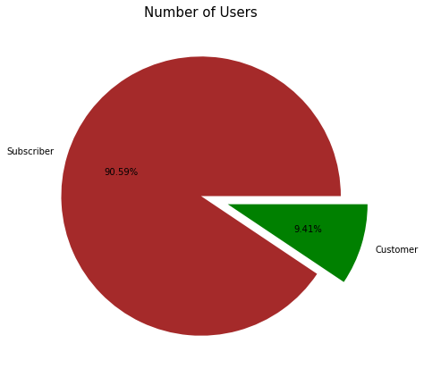

```python
labels=Data['user_type'].value_counts().index
colors=['brown','green']
explode=[0,0.2]
values=Data['user_type'].value_counts().values
plt.figure(figsize=(7,10))
plt.pie(values,explode=explode,labels=labels,colors=colors,autopct='%1.2f%%')
plt.title('Number of Users',fontsize=15)
plt.show()
```

Most of the bike users are subscribers 90% ,but customer 9.4%

# Distribution of Trip

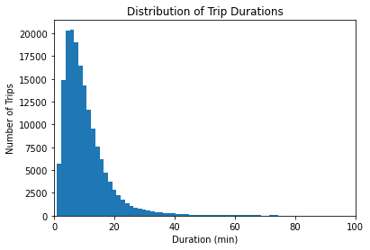

```python
plt.hist(data = Data, x = 'duration_minites',bins=1000)
plt.title('Distribution of Trip Durations')
plt.xlim(xmin=0, xmax = 100)
plt.xlabel('Duration (min)')
plt.ylabel('Number of Trips')
plt.figure(figsize=[7,7])
plt.show()
```

that most customer use the bike for 1 to 20 and 30 minutes